# 代码随想录 Chapter1 数组Array

## LC27 Remove Element

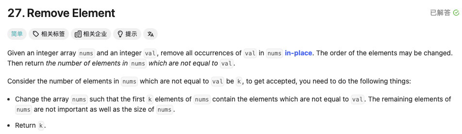

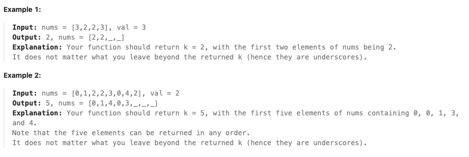

### 法1: 暴力解法

```python
class Solution:
    def removeElement(self, nums: list[int], val: int) -> int:
        k = len(nums)
        for i in range(len(nums)):
            while(nums[i] == val):
                nums[i] = 200
                k -= 1
        nums.sort()
        return k
```

时间复杂度: O($N^2$)  
空间复杂度：O(1)

注：

- 其实也可以用del nums[i] 的方法写暴力，但是比较麻烦。原因是delete 某个元素过后，nums的长度会发生改变，很影响你for loop 的遍历（比如下面这个错误的代码）。所以我们只是巧妙地运用了0 <= nums[i] <= 50 这个限制条件，把和val相等的数字都改成200，这样数组长度不变。
- 另外这里目的是让我们学会del库函数的实现，carl说可以用库函数做的就别用库函数。

```python
nums = [1,3,5,6]
del nums[0]
nums
```

```
[3, 5, 6]
```

```python
class Solution:
    def removeElement(self, nums: list[int], val: int) -> int:
        # n 为最初的len(nums)
        n = len(nums)
        k = len(nums)
        for i in range(n):
            while nums[i] == val:
                del nums[i]
                k -= 1

        # 补齐nums的长度
        underscores = ['_' for _ in range(n - k)]

        nums.extend(underscores)
        return k

# test
nums = [1,3,5,6]
val = 3
s = Solution()
s.removeElement(nums, val)
```

[output not shown]

### 法2: 双指针 fast, slow

双指针有left right, fast slow, 后面有专门的章节讲。

**双指针法（快慢指针法）**： 通过一个快指针和慢指针在一个for循环下完成两个for循环的工作。

定义快慢指针

**快指针**：fast always move to the right every time!

**慢指针**：slow 的移动是有条件的。  
在本题中，只有当nums[fast] != val的时候slow才会往右移动一格。换句话说，**如果nums[fast] == val，那么slow就不动，默默等待被替换**。

```python
# 写法1: use while loop

class Solution:
    def removeElement(self, nums: list[int], val: int) -> int:

        slow, fast = 0, 0

        while fast < len(nums):
            if nums[fast] != val:
                nums[slow] = nums[fast]
                # 如果nums[fast] == val，那么slow就不动，默默等待被替换
                slow += 1
            # fast moves to the right every time
            fast += 1

        # slow指针相当于在计数有多少个number != val
        return slow

# test
nums = [1,3,5,6]
val = 3
s = Solution()
s.removeElement(nums, val)
```

```
3
```

再次强调快慢指针的精妙之处：

- fast index相当于在遍历数组，
- slow index在nums[fast] == val的时候不动，默默等待被替换。另外，slow指针相当于在计数有多少个number != val。

```python
# 写法2: use for loop

class Solution:
    def removeElement(self, nums: list[int], val: int) -> int:

        slow, fast = 0, 0

        # fast 遍历数组的功能在这里体现，然后不需要 fast += 1 了
        for fast in range(len(nums)):
            if nums[fast] != val:
                nums[slow] = nums[fast]
                # 如果nums[fast] == val，那么slow就不动，默默等待被替换
                slow += 1

        # slow指针相当于在计数有多少个number != val
        return slow
```

重点：fast 指针遍历数组的功能在这里体现，然后不需要 fast += 1 了

时间复杂度: O($N$)  
空间复杂度：O(1)

# Day2 (Jan 11)| 977.有序数组的平方, 209.长度最小的子数组, 325, 59.螺旋矩阵II

## LC977 Squares of a Sorted Array

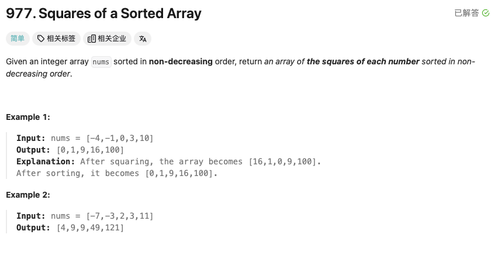

题目建议： 本题关键在于理解双指针思想

题目链接：https://leetcode.cn/problems/squares-of-a-sorted-array/

文章讲解：https://programmercarl.com/0977.%E6%9C%89%E5%BA%8F%E6%95%B0%E7%BB%84%E7%9A%84%E5%B9%B3%E6%96%B9.html

视频讲解： https://www.bilibili.com/video/BV1QB4y1D7ep

### 法1: 暴力排序

每个数平方之后，排个序

这个时间复杂度是 O(n + nlogn)， 可以说是O(nlogn)的时间复杂度，但为了和下面双指针法算法时间复杂度有鲜明对比，我记为 O(n + nlog n)。

```python
class Solution:
    def sortedSquares(self, nums: list[int]) -> list[int]:
        # method1: 暴力解法 -- 先平方，再排序

        for i in range(len(nums)):
            nums[i] = nums[i] ** 2
        nums.sort()
        return nums
```

```python
# 另一种写法

class Solution:
    def sortedSquares(self, nums: list[int]) -> list[int]:
        return sorted(x*x for x in nums)
```

### 法2: 双指针 -- left，right

怎么想到双指针？

- 数组其实是有序的， 只不过负数平方之后可能成为最大数了。那么数组平方的最大值就在数组的两端，不是最左边就是最右边，不可能是中间。
- 此时可以考虑双指针法了，而且使用left和right指针，从两边逐步向中间合拢的过程。
- 因为最大值肯定在两端，所以由大到小写出新的数组。

```python
class Solution:
    def sortedSquares(self, nums: list[int]) -> list[int]:
        # 法2: 双指针（自己写的）
        res = []
        left, right = 0, len(nums) - 1

        while left <= right:
            if nums[left] ** 2 > nums[right] ** 2:
                res.append(nums[left] ** 2)
                left += 1
            else:
                res.append(nums[right] ** 2)
                right -= 1

        # now res is of descending order, reverse it
        res.reverse() # O(N)的操作

        return res

# test
nums = [-4,-1,0,3,10]
s = Solution()
s.sortedSquares(nums)
```

```
[0, 1, 9, 16, 100]
```

自己写的代码思路很清晰，但是如果不用reverse()这个库函数的话，就得看随想录的写法。  
要想不用reverse，就得多一个存放结果的指针，每次向前平移一位。

```python
class Solution:
    def sortedSquares(self, nums: list[int]) -> list[int]:
        # 法2: 双指针（随想录）
        res = [0] * len(nums) # 需要提前定义列表，存放结果
        left, right = 0, len(nums) - 1
        i = len(nums) - 1     # 存放位置

        while left <= right:
            if nums[left] ** 2 > nums[right] ** 2:
                res[i] = nums[left] ** 2
                left += 1
            else:
                res[i] = nums[right] ** 2
                right -= 1

            # 从后往前填充列表
            i -= 1

        return res
```

这个的时间复杂度为O(n)，相对于暴力排序的解法O(n + nlog n)还是提升不少的。

## LC209 Minimum Size Subarray Sum

题目建议： 本题关键在于理解滑动窗口，这个滑动窗口看文字讲解 还挺难理解的，建议大家先看视频讲解。

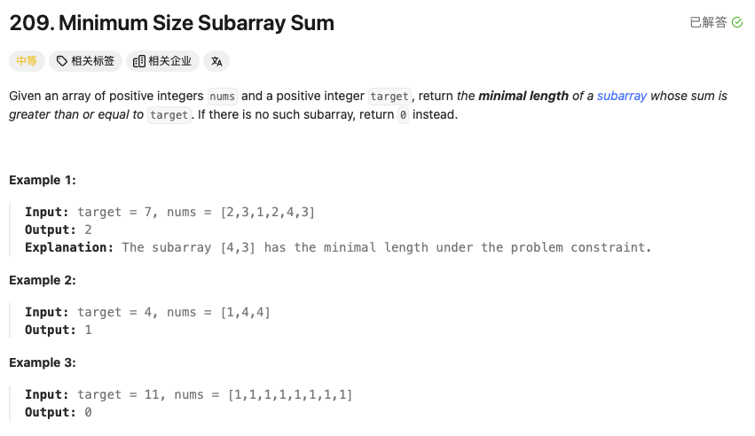

### 法1: 暴力

在暴力解法中，是一个for循环滑动窗口的起始位置(start)，一个for循环为滑动窗口的终止位置(end)，用两个for循环 完成了一个不断搜索区间的过程

### 法2: 滑动窗口（from 随想录）

文章讲解：https://programmercarl.com/0209.%E9%95%BF%E5%BA%A6%E6%9C%80%E5%B0%8F%E7%9A%84%E5%AD%90%E6%95%B0%E7%BB%84.html  
视频讲解：https://www.bilibili.com/video/BV1tZ4y1q7XE

所谓**滑动窗口（sliding window)**，就是不断的调节子序列的起始位置和终止位置，从而得出我们要想的结果。本质也是双指针，只不过是取这两个指针之间的部分，像一个在滑动的窗口。

所以现在我们有**三种双指针**：  
1）left, right  
2) slow, fast  
3) start, end (sliding window)

**思路：**

用一个for loop 去做两个for loop的事情（有人说就是两层for loop + 剪枝）

`for j in range(len(nums)):`

- 这里的 $j$ 表示起始位置还是终止位置？
  - 如果j表示起始位置，那么终止位置依然要把所有位置遍历一遍，跟暴力解法没区别
  - 所以j只能表示**终止位置**
  - 本题的重点在于如何移动起始位置

```python
'''
写一个伪代码

res = max
i = 0 # 初始位置i
for j in range(len(nums)):
    # 把nums[j]加到res里面
    sum += nums[j]

    **while** sum >= target: # 这里用while因为要持续向后移动起始位置，更新滑动窗口长度来找到最小
        sublen = j - i + 1
        # update res
        res = min(res, sublen)
        # i往右移动
        sum -= nums[i]
        i += 1

return res
'''
```

```
'\n写一个伪代码\n\nres = max\ni = 0 # 初始位置i\nfor j in range(len(nums)):\n    # 把nums[j]加到res里面\n    sum += nums[j]\n\n    while sum >= target:\n        sublen = j - i + 1\n        # update res\n        res = min(res, sublen)\n        # i往右移动\n        sum -= nums[i]\n        i += 1\n\nreturn res\n'
```

Remark: **while** sum >= target，用while不用if，原因是yao持续向后移动起始位置，更新滑动窗口长度来找到最小。

e.g. nums = [1, 1, 1, 1, 100], target = 100

```python
class Solution:
    def minSubArrayLen(self, target: int, nums: list[int]) -> int:

        # 法2: 滑动窗口
        if sum(nums) < target:
            return 0

        res = len(nums)
        sum_ = 0
        i = 0 # start pointer

        for j in range(len(nums)): # end pointer
            sum_ += nums[j]

            # 持续向后移动起始位置，以更新滑动窗口的大小
            while sum_ >= target:
                sublen = j - i + 1
                # update res to be the minimum length
                res = min(res, sublen)

                # start pointer i moves one step to the right
                sum_ -= nums[i]
                i += 1

        return res
```

**Comments：**

1. Here, `nums` and `target` are both **positive integers,** 所以滑动窗口适用。
2. 如果`nums`可以有负数的话，问题会复杂很多。如果我们还用这种方法就会出问题，比如下面这个例子。
   - 最开始，`i = 0`, `j = 0`
   - 然后，`i = 0`, `j` 逐渐搜索到 `j = 4`, `sum = 2` 此时进入 while loop
     - `sublen = 5`, `res = 5`
   - 然后 `i = 1`, `sum = 1` 直接出了while loop
     - 也就是说我们的程序认为在以`j = 4` 结尾的滑动窗口中，满足条件的最短子数组长度是5
     - 这显然是错误的，因为如果把`i` 再往后一位的话，`sum = 3` （又会增加），所以满足条件的最短子数组长度是2
3. 我的评价是：由于`nums` and `target` are both positive integers，所以当`j`不动时，不断移动`i`使我们的区间变短，**当前的sum一定是越来越小的**。所以我们只要一碰到`sum < target`, 就立刻跳出while loop，此时我们**能保证res = 以`j`结尾的subarray中，满足条件的最短子数组长度**。然后终止位置`j` 向后移动一位，继续寻找以下一个`j`结尾的最短的窗口长度。

   所以这道题的思路很明确：j一个一个遍历数组，对于每一个`j`，找到以`j`结尾的subarray中, 满足条件的最短子数组长度.

   如果没有positive 这个条件，不断移动`i`使我们的区间变短，当前sum不一定是越来越小的（这里是2，1，3），所以这个方法不行。

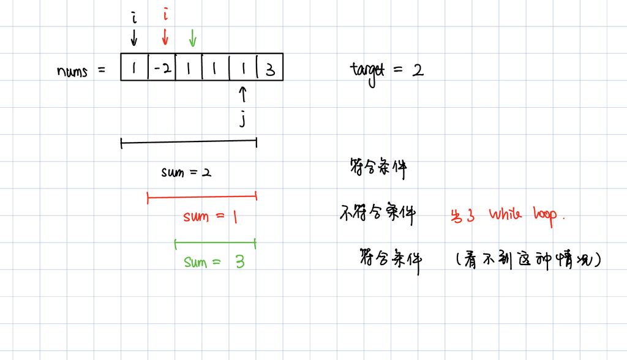

这里我想补充一道看起来从题面上很类似的题，但解法上完全不同。

## LC325 Maximum Size Subarray Sum Equals k

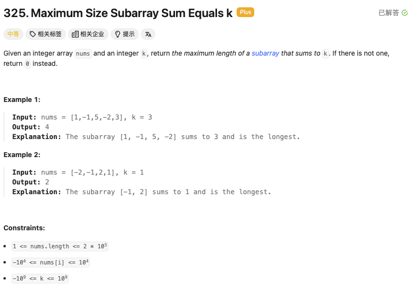

这道题就不能用刚才LC209的滑动窗口了，因为这里的nums 和 k 都可以是负数，根据类似的逻辑，滑动窗口不适用。

### 方法: prefixsum + hashtable

from Leetcode 题解，每次一用prefixsum就特别难想，还是上图吧。

Preliminary: What is **prefixsum**?

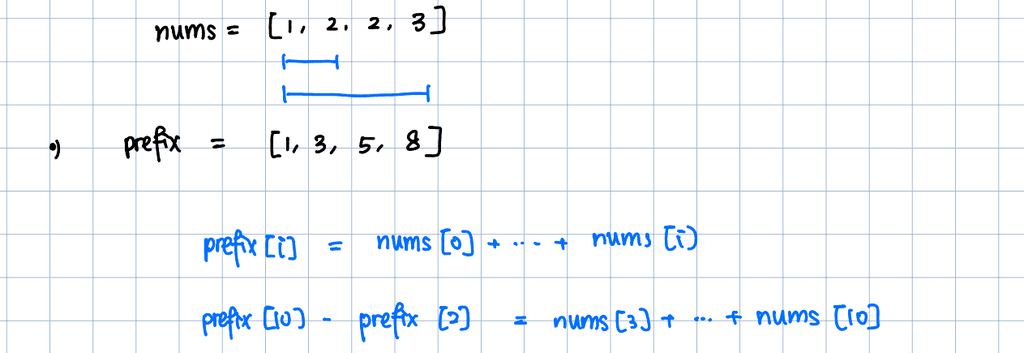

prefixsum 通常都是用来做差，和我们的程序目标产生相关性的。

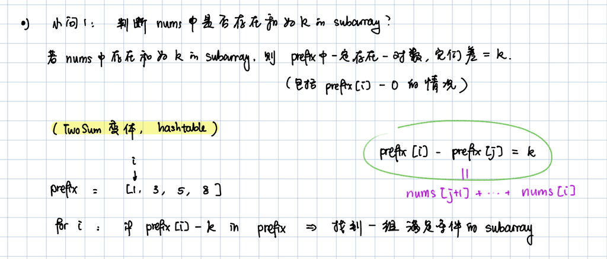

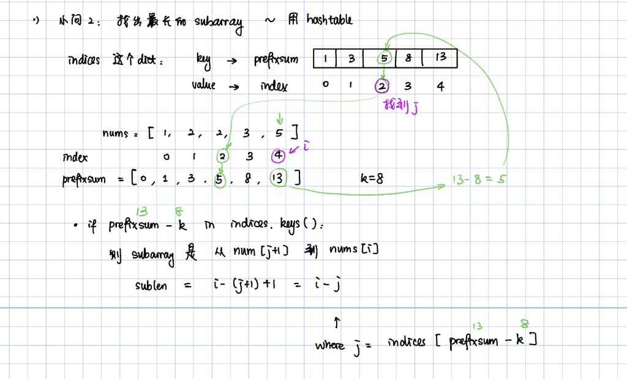

所以coding思路：

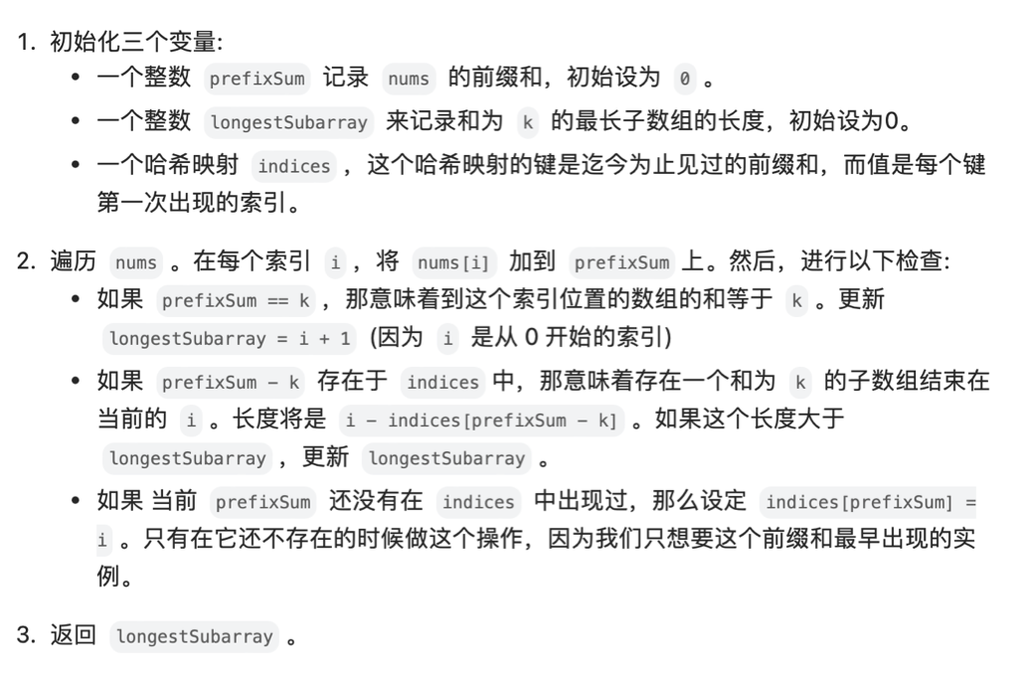

```python
# solution
class Solution:
    def maxSubArrayLen(self, nums: list[int], k: int) -> int:
        # prefixsum + hashtable
        prefixsum = 0
        res = 0
        indices = {} # dict, hashtable: store the value of prefixsum and its index

        for i in range(len(nums)):
            prefixsum += nums[i]

            # 如果prefixsum不在indices里面，那么就加进去
            # 如果已经在了，那么就不用管了，因为我们要找的是最长的subarray （见下面remark）
            if prefixsum not in indices.keys():
                indices[prefixsum] = i # key is the prefixsum, value is the index

            # 数组从0到i的和等于k
            if prefixsum == k:
                sublen = i+1

            # 数组从indices[prefixsum - k]+1 到i 的和等于k
            if prefixsum - k in indices.keys():
                sublen = i - indices[prefixsum - k]
                # update res
                res = max(res, sublen)

        return res
```

**Comment**: 这里跟two sum 那道题很像的一点是hashtable的巧用 -- **key是某个东西的数值，value反而是index**。这是因为我们想通过prefixsum的值来找它在prefixsum数组中的位置，进而找到满足条件的subarray的初始和终止位置。当我们想通过A来找B时，应该把A设成dictionary 的 key，B设成value。

Remark:

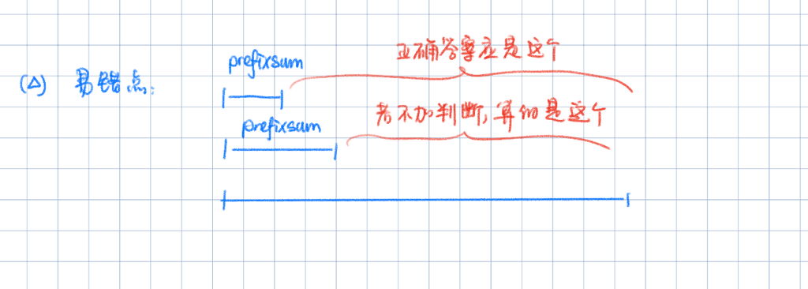

## LC59 Spiral Matrix II

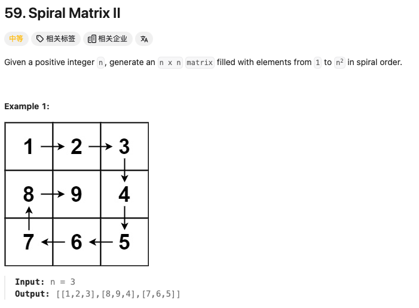

本题并不涉及到什么算法，就是模拟过程，但却十分考察对代码的掌控能力。

而求解本题依然是要坚持循环不变量原则。

模拟顺时针画矩阵的过程:

填充上行从左到右  
填充右列从上到下  
填充下行从右到左  
填充左列从下到上  
由外向内一圈一圈这么画下去。

这里一圈下来，我们要画每四条边，这四条边怎么画，每画一条边都要坚持一致的左闭右开，或者左开右闭的原则，这样这一圈才能按照统一的规则画下来。

那么我按照左闭右开的原则，来画一圈，大家看一下：

[figure not shown]

继续思路：我们设一圈 = 画了四条边，那么一共要画多少圈呢？答案是 `n // 2` 圈。 这是因为矩阵的边长 = $n$, 每填充一圈就会少左右两边的格子，所以长度 / 2（举一个 $n = 4$ 的例子就明白了）。  
这里还有一个小点要注意：

- 当n为偶数的时候正好填充完（e.g. $n = 4$）
- 当n为奇数的时候，最后会剩下最中间的一个格子（e.g. $n = 3$），所以要加一个判断语句处理这种情况 (`mid = n // 2` )。

**伪代码**：注意这里i代表行index，j代表列index，`(i, j)` 和`(startx, starty)` 对应。

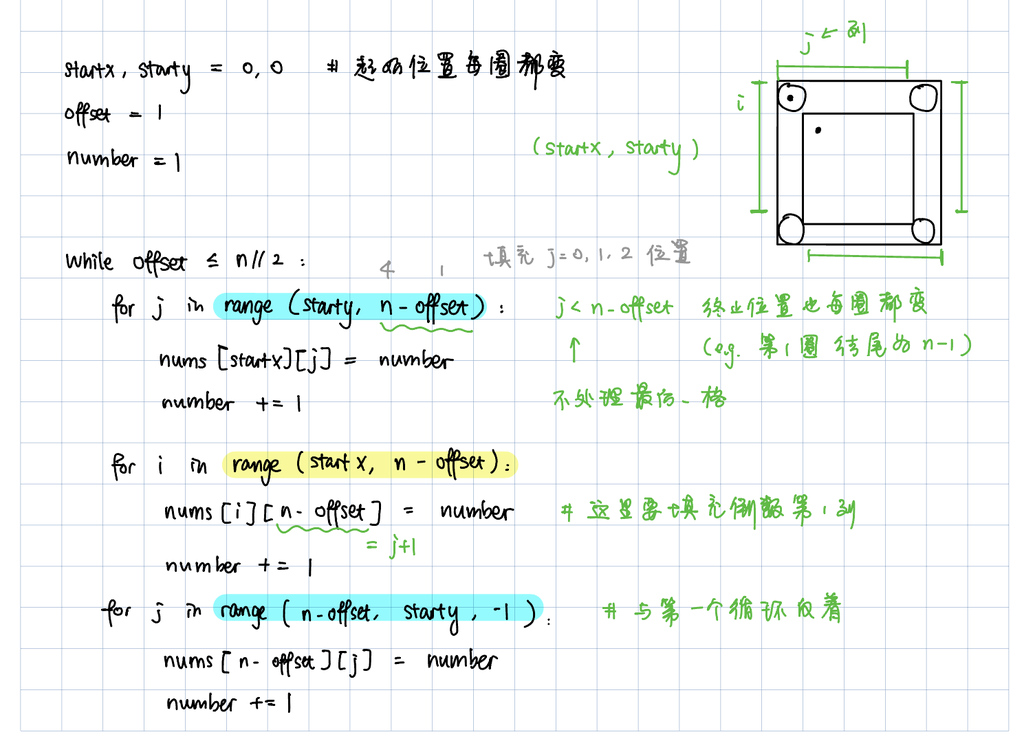

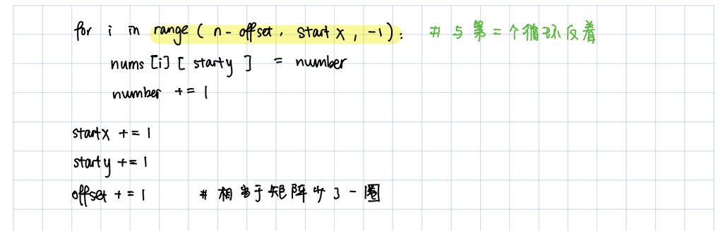

```python
class Solution:
    def generateMatrix(self, n: int) -> list[list[int]]:
        nums = [[0 for _ in range(n)] for _ in range(n)]
        startx, starty = 0, 0
        mid = n // 2
        offset = 1 # 这是第几圈
        number = 1 # 要填充的数字


        while offset <= n // 2: # 从第一圈开始, 一共n // 2圈
            # 填充上行从左到右, 左闭右开
            for j in range(starty, n - offset, +1):
                nums[startx][j] = number
                number += 1
            # 填充右列从上到下
            for i in range(startx, n - offset, +1):
                nums[i][n - offset] = number
                number += 1
            # 填充下行从右到左
            for j in range(n - offset, starty, -1):
                nums[n - offset][j] = number
                number += 1
            # 填充左列从下到上
            for i in range(n - offset, startx, -1):
                nums[i][starty] = number
                number += 1

            startx += 1
            starty += 1
            offset += 1

        # n是奇数时，中间剩一个格子没填充
        if n % 2 != 0:
            nums[mid][mid] = number

        return nums
```

## 总结

### 1. List vs. Array

### Python List

- A **list** is a built-in Python data structure that can hold items of different data types.
- Lists are dynamic; they can grow or shrink, and elements can be of **any type**, including other lists.
- They come with a variety of built-in methods for manipulation such as adding `append()`, removing `remove()`, and changing `extend()` `pop()` elements, and more.
- In Python, lists are created using square brackets `[]`, like so: `my_list = [1, 'two', 3.0]`.

### Python Array

In Python, an **array** is a data structure available through the `array` module that stores elements of **the same data type**:

- An array is more memory efficient and can offer better performance for certain tasks compared to lists, especially when dealing with a large number of elements.
- Arrays are particularly useful when you're working with **numerical data** and require efficient storage and manipulation of elements.
- To use arrays in Python, you must import the `array` module with the statement `import array`.

For example, creating an array of integers with the `array` module looks like this:

```
from array import array
int_array = array('i', [1, 2, 3, 4])
```

### Python Array in LeetCode

- In LeetCode problems, when "array" is mentioned, it usually refers to a concept similar to lists, but the term is used in a more general, language-agnostic way.
- Unlike in Python's `array` module where arrays are homogenous, in LeetCode "array" problems, you can use Python lists without importing any module.
- The "array" problems are often about manipulating indexed collections of items, typically assuming they are of the same type for simplicity.
- In LeetCode, when you're solving "array" problems, you just use a Python list as you normally would.

For example, a LeetCode problem might ask you to manipulate an array of integers. In Python, you would use a list:

```
# LeetCode "array" problem using a Python list
nums = [2, 7, 11, 15]
```

需要两点注意的是

- 数组下标都是从0开始的。Indexing Starts at Zero.
- 数组内存空间的地址是连续的。正是因为数组的在内存空间的地址是连续的，所以我们在删除或者增添元素的时候，就难免要移动其他元素的地址  
  (**Contiguous Memory Allocation**: While Python lists are not arrays in the traditional sense, they behave similarly in that they allow for efficient indexing. The difference is that **Python lists** can grow or shrink dynamically, and they can hold items of different types.)

### 2. 三种方法

1. **二分法**：特殊的双指针-- left，right & mid
2. **双指针**：
   - **left，right** （也有不是二分法的左右指针）
   - **fast, slow** (fast 永远遍历整个数组)  
     双指针法（快慢指针法）在数组和链表的操作中是非常常见的，很多考察数组和链表操作的面试题，都使用双指针法。
   - **start, end**(滑动窗口)
3. **滑动窗口**（本质还是双指针，只不过是取start, end 中间的部分）

https://code-thinking-1253855093.file.myqcloud.com/pics/数组总结.png

```python
pip install nbconvert
```

```python
# run in terminal
jupyter nbconvert /Users/xingqitian/Desktop/Python/Leetcode/Ch1_Array.ipynb --to python
```

[output not shown]